# NYC Citi Bike Report

```r
library(lubridate)
library(tibble)
library(tidyverse)
library(tsibble)
library(tsibbledata)
library(slider)
library(leaflet)
library(raster)
library(sp)
library(dplyr)
```

```r
# Add derived columns to dataset

nyc_bikes_df <- nyc_bikes %>%
  mutate(
    start_date = as_date(start_time),
    stop_date = as_date(stop_time),
    start_year = year(start_time),
    start_quarter = quarter(start_time),
    start_month = month(start_time,
                        label = TRUE,
                        abbr = FALSE),
    start_weekday = wday(start_time,
                    week_start = 1,
                    label = TRUE,
                    abbr = FALSE),
    start_hour = hour(start_time),
    start_minute = minute(start_time),
    start_hour_numeric = (start_hour + (start_minute/60)),
    trip_duration = (stop_time - start_time),
    age = start_year - birth_year,
    age_group = case_when(age  >= 65 ~ "65+",
                          age  >= 55 ~ "55 - 64",
                          age  >= 45 ~ "45 - 54",
                          age  >= 35 ~ "35 - 44",
                          age  >= 25 ~ "25 - 34",
                          age  >= 18 ~ "18 - 24",
                          TRUE ~ NA_character_
    )
  )
```

# Introduction

This report uses a sample of NYC Citi Bike usage data to assess the following questions:

- What is the pattern of bike hires over time?
- Do bike hire patterns differ between bike rider demographics?
- What is the geographical spread of the start points of bike hires?
- Any other insights?

The report gives a broad overview of activity over the year and by time of day, and highlights areas which might benefit from more in-depth analysis.

# Background

### About NYC Citi Bike

Citi Bike is New York City’s bike share system. Launched in 2013, it has over 140,000 members, and in July 2020 it recorded its 100 millionth trip.

**Website:** https://www.citibikenyc.com/about

### About the dataset

This report uses a sample which details the usage of 10 bikes throughout 2018.

The dataset is in the public domain, and contains no person-identifiable information.

**Link:** https://rdrr.io/github/tidyverts/tsibbledata/man/nyc_bikes.html

# Analysis of the data

### Pattern of bike hires over time

**Number of trips per day in 2018**

As might be expected, there are more trips per day in summer than in winter, with a peak of 47 trips on the 31st of July.

The average shown in red suggests that usage plateaus through the summer months - it might be worth investigating further to see if this has any relation to the availability of bikes (for example, if demand for trips exceeds the number of bikes available).

```r
 #Date with HIGHEST number of trips
  #nyc_bikes_df %>%
  #index_by(start_date) %>%
  #summarise(number_of_trips = n()) %>%
  #arrange(desc(number_of_trips)) %>%
  #head(1)

# Dates with LOWEST number of trips
  #nyc_bikes_df %>%
  #index_by(start_date) %>%
  #summarise(number_of_trips = n()) %>%
  #filter(number_of_trips == 1)

#Total number of trips
total_trips <- tibble(nyc_bikes_df %>%
  summarise(number_of_trips = n())
)
total_trips <- total_trips %>%
  summarise(number_of_trips = sum(number_of_trips))
```

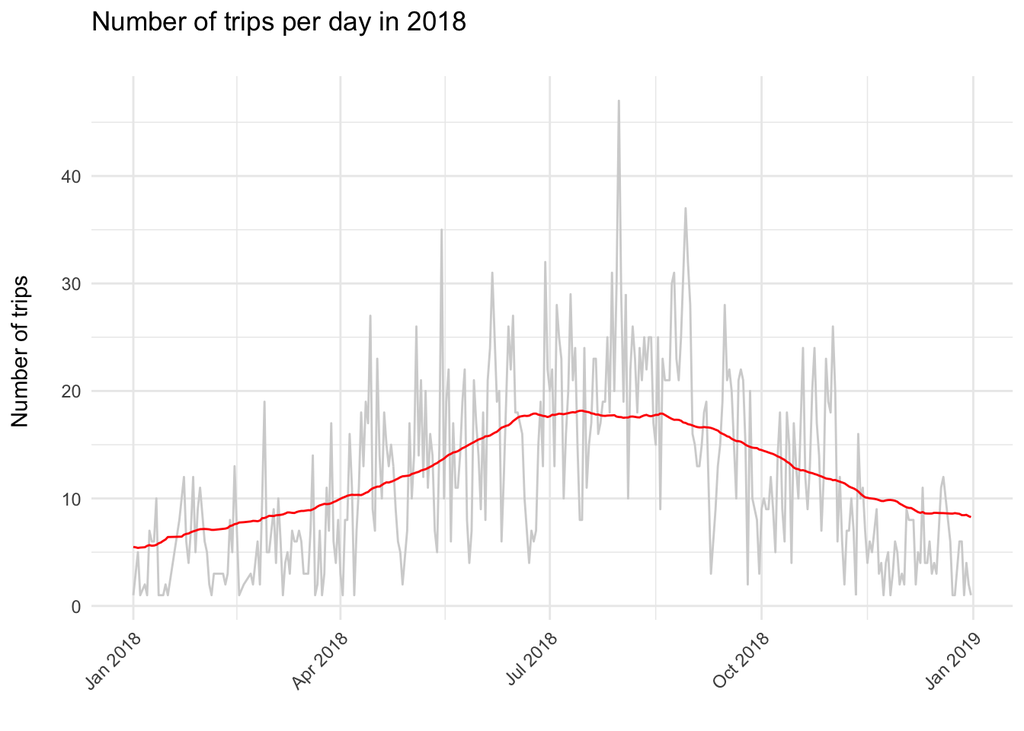

```r
# Source data for trips per day
nyc_bikes_df %>%
  index_by(start_date) %>%
  summarise(number_of_trips = n()) %>%
  mutate(
    trips_moving_average = slide_dbl(
      number_of_trips,
      ~ mean(., na.rm = TRUE),
      .before = 75,
      .after = 75,
      .complete = FALSE
    )
  ) %>%
ggplot() +
  aes(x = start_date, y = number_of_trips) +
  geom_line(colour = "light grey") +
  geom_line(aes(y = trips_moving_average), colour = "red") +
  theme_minimal() +
  theme(axis.text.x = element_text(angle = 45, hjust = 1)) +
  labs(
    title = "Number of trips per day in 2018 \n",
    x = "",
    y = "Number of trips \n"
  )
```

**Number of trips by time of day**

Again, this follows a pattern you might expect - there are peaks around typical commuting hours, with usage rising sharply before the morning peak, and tailing off more gradually in the evening.

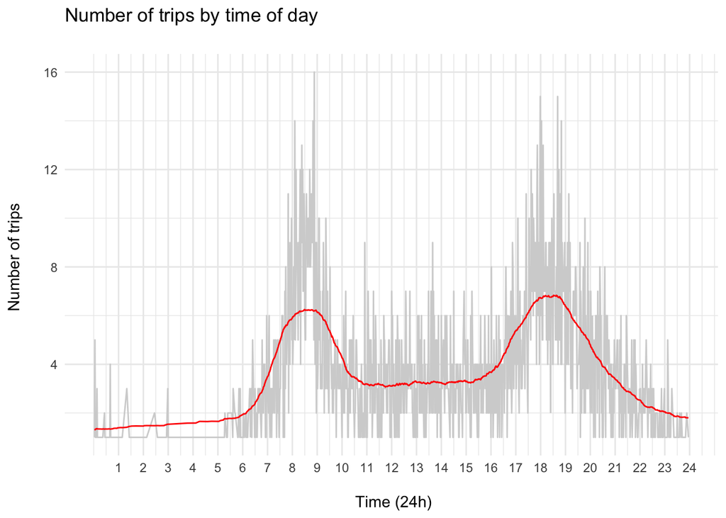

```r
# source data for trips by time of day
nyc_bikes_df %>%
  index_by(start_hour_numeric) %>%
  summarise(number_of_trips = n()) %>%
  mutate(
    trips_moving_average = slide_dbl(
      number_of_trips,
      ~ mean(., na.rm = TRUE),
      .before = 75,
      .after = 75,
      .complete = FALSE
    )
  ) %>%
ggplot() +
  aes(x = start_hour_numeric, y = number_of_trips) +
  geom_line(colour = "light grey") +
  geom_line(aes(y = trips_moving_average), colour = "red") +
  scale_x_continuous(breaks = 1:24) +
  theme_minimal() +
  labs(
    title = "Number of trips by time of day \n",
    x = "\n Time (24h)",
    y = "Number of trips \n"
  )
```

### Demographic analysis

**Total number of trips in 2018 by gender**

The first figure to note is that more than three times as many trips were made by males than females, which feels like it should be a cause for concern.

| Gender | Number of trips |
| --- | --- |
| Female | 930 |
| Male | 3,069 |

Records where gender was recorded as “Unknown” have been excluded, as I’m not familiar enough with how the data was recorded to be sure if these represent a deliberate choice by the user, or if they represent missing data.

```r
nyc_summ_gender <- tibble( nyc_bikes_df %>%
  filter(gender!= "Unknown") %>%
  group_by(gender) %>%
  summarise(number_of_hires = n()) )

nyc_summ_gender <- nyc_summ_gender %>%
  group_by(gender) %>%
  summarise(number_of_hires = sum(number_of_hires))
```

**Pattern of bike hires over time by gender**

If we repeat the analysis on usage over the year and by time of day but split the results by gender, we see a broadly similar pattern.

While number of trips at the start of the year appear higher for females, it should be noted that the number of trips per day are in the low single figures.

This would merit further statistical analysis using a larger sample with more female respondents.

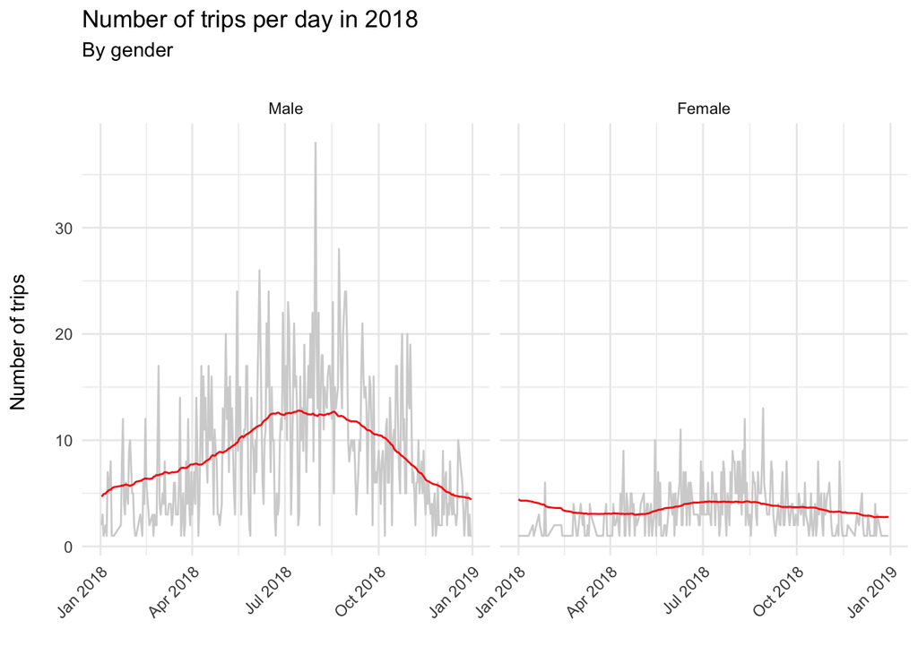

```r
# Source data for trips per day
nyc_bikes_df %>%
  filter(gender!= "Unknown") %>%
  index_by(start_date) %>%
  group_by(gender) %>%
  summarise(number_of_trips = n()) %>%
  mutate(
    trips_moving_average = slide_dbl(
      number_of_trips,
      ~ mean(., na.rm = TRUE),
      .before = 75,
      .after = 75,
      .complete = FALSE
    )
  ) %>%
ggplot() +
  aes(x = start_date, y = number_of_trips) +
  geom_line(colour = "light grey") +
  geom_line(aes(y = trips_moving_average), colour = "red") +
  theme_minimal() +
  theme(axis.text.x = element_text(angle = 45, hjust = 1)) +
  labs(
    title = "Number of trips per day in 2018 ",
    subtitle = "By gender \n",
    x = "",
    y = "Number of trips \n"
  ) +
  facet_grid(~gender)
```

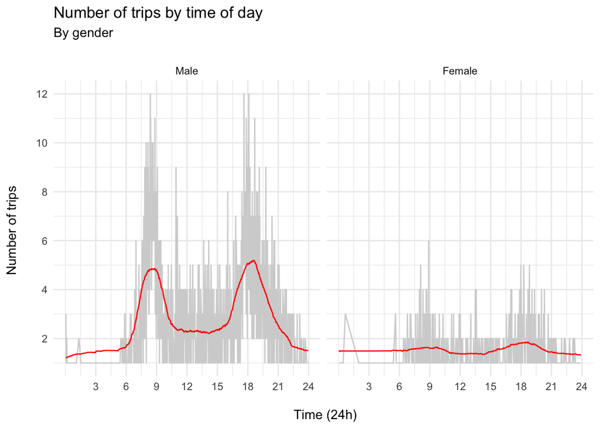

```r
# source data for trips by time of day
nyc_bikes_df %>%
  filter(gender!= "Unknown") %>%
  index_by(start_hour_numeric) %>%
  group_by(gender) %>%
  summarise(number_of_trips = n()) %>%
  mutate(
    trips_moving_average = slide_dbl(
      number_of_trips,
      ~ mean(., na.rm = TRUE),
      .before = 75,
      .after = 75,
      .complete = FALSE
    )
  ) %>%
ggplot() +
  aes(x = start_hour_numeric, y = number_of_trips) +
  geom_line(colour = "light grey") +
  geom_line(aes(y = trips_moving_average), colour = "red") +
  scale_x_continuous(breaks = c(3, 6, 9, 12, 15, 18, 21, 24)) +
  scale_y_continuous(breaks = c(2, 4, 6, 8, 10, 12)) +
  theme_minimal() +
  labs(
    title = "Number of trips by time of day",
    subtitle = "By gender \n",
    x = "\n Time (24h)",
    y = "Number of trips \n"
  ) +
  facet_grid(~gender)
```

**Number of trips by age of user**

The people who made trips in this sample range in age from 19 to 71 (excluding a couple of people aged over 130, I’ve assumed these are data entry errors!)

The majority of trips were made by people in the 25-34 age bracket.

```r
nyc_summ_age_group <- tibble( nyc_bikes_df %>%
  filter(age < 130) %>%
  group_by(age, age_group) %>%
  summarise(number_of_trips = n()) )

nyc_summ_age <- nyc_summ_age_group %>%
  group_by(age) %>%
  summarise(number_of_trips = sum(number_of_trips))

#nyc_summ_age %>%
#  slice_max(age)

#nyc_summ_age %>%
#  slice_min(age)
```

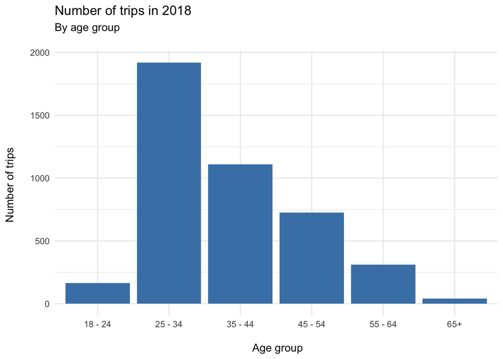

```r
ggplot(nyc_summ_age_group) +
  aes(x = age_group, y = number_of_trips) +
  geom_col(fill = "steel blue") +
  theme_minimal() +
  labs(
    title = "Number of trips in 2018",
    subtitle = "By age group \n",
    x = "\n Age group",
    y = "Number of trips \n"
  )
```

**Pattern of bike hires over the year by age group**

We can clearly see the summer peak in the 25-54 age groups; the number of trips in other age groups is too small to draw any firm conclusions.

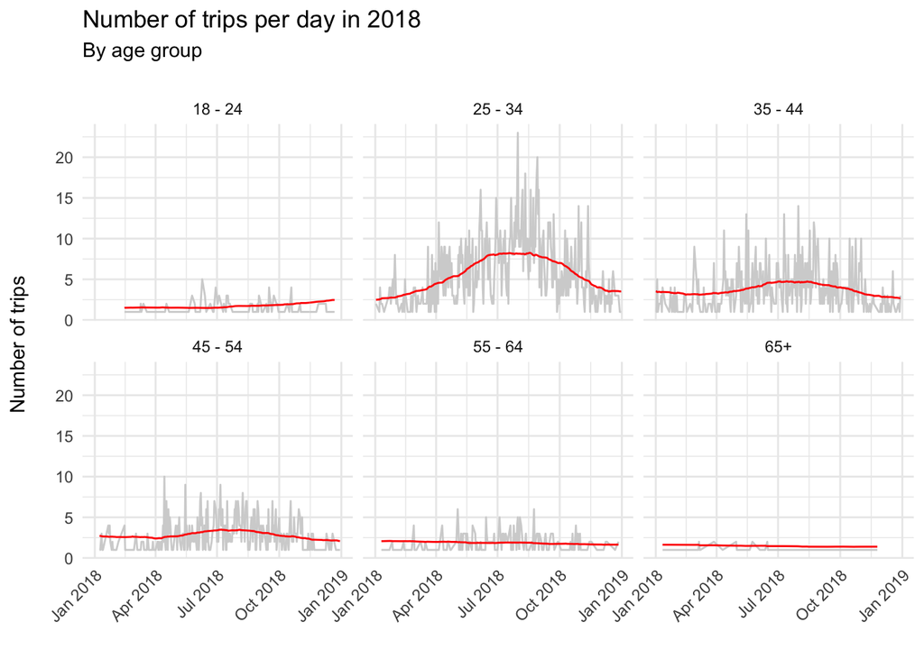

```r
# Source data for trips per day
nyc_bikes_df %>%
  index_by(start_date) %>%
  group_by(age_group) %>%
  summarise(number_of_trips = n()) %>%
  mutate(
    trips_moving_average = slide_dbl(
      number_of_trips,
      ~ mean(., na.rm = TRUE),
      .before = 75,
      .after = 75,
      .complete = FALSE
    )
  ) %>%
ggplot() +
  aes(x = start_date, y = number_of_trips) +
  geom_line(colour = "light grey") +
  geom_line(aes(y = trips_moving_average), colour = "red") +
  theme_minimal() +
  theme(axis.text.x = element_text(angle = 45, hjust = 1)) +
  labs(
    title = "Number of trips per day in 2018 ",
    subtitle = "By age group \n",
    x = "",
    y = "Number of trips \n"
  ) +
  facet_wrap(~age_group)
```

**Pattern of bike hires during the day by age group**

The commuting-hours peaks in activity can be most clearly seen, as might be expected, in the 25-54 age ranges.

Usage amongst other age groups throughout the day is more consistent, but there are a very small number of trips in this sample.

It might be interesting to do further analysis on, for example, the 45-64 age groups, to assess whether anything could be done to encourage uptake, particularly outside peak hours.

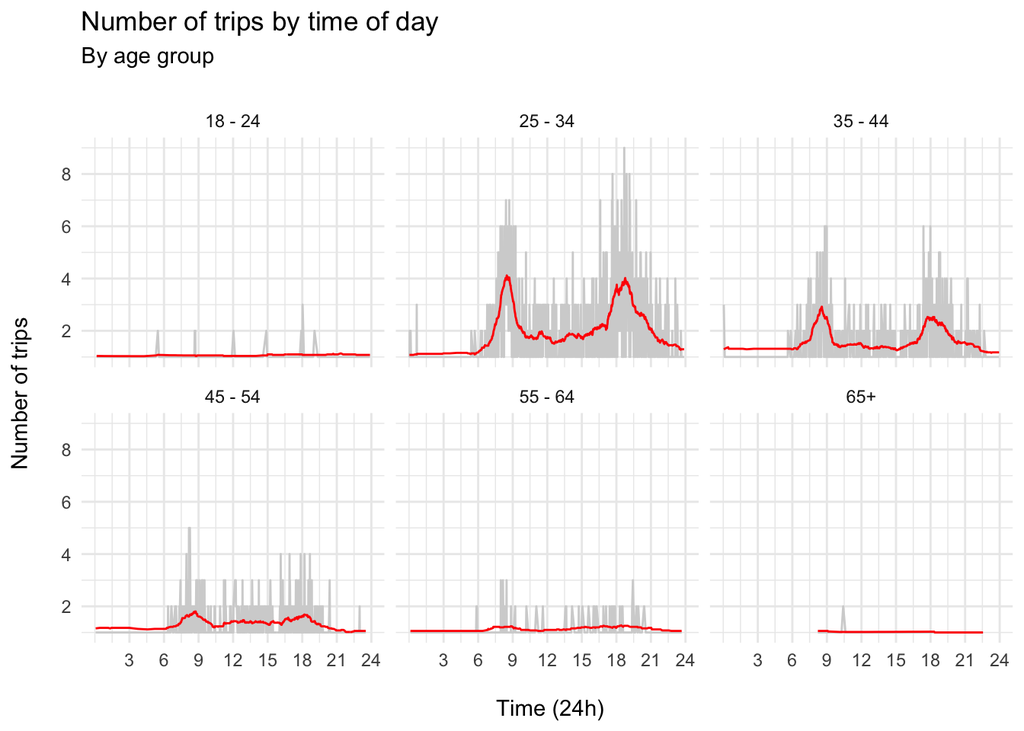

```r
# source data for trips by time of day
nyc_bikes_df %>%
  index_by(start_hour_numeric) %>%
  group_by(age_group) %>%
  summarise(number_of_trips = n()) %>%
  mutate(
    trips_moving_average = slide_dbl(
      number_of_trips,
      ~ mean(., na.rm = TRUE),
      .before = 25,
      .after = 25,
      .complete = FALSE
    )
  ) %>%
ggplot() +
  aes(x = start_hour_numeric, y = number_of_trips) +
  geom_line(colour = "light grey") +
  geom_line(aes(y = trips_moving_average), colour = "red") +
  scale_x_continuous(breaks = c(3, 6, 9, 12, 15, 18, 21, 24)) +
  scale_y_continuous(breaks = c(2, 4, 6, 8)) +
  theme_minimal() +
  labs(
    title = "Number of trips by time of day",
    subtitle = "By age group \n",
    x = "\n Time (24h)",
    y = "Number of trips \n"
  ) +
  facet_wrap(~age_group)
```

### Geographical spread of the start points of bike hires

The map below shows the starting point (start station) of all trips in the sample.

Deeper colours indicate a higher number of trips - click on the marker to see the number.

The highest number of trips recorded at a start station was 434, the lowest was 1.

```r
# Get distinct list of start stations with number of trips
start_locations <- tibble(nyc_bikes_df %>%
  group_by(start_station, start_lat, start_long) %>%
  summarise(number_of_trips = n())
)
start_locations <- start_locations %>%
  group_by(start_station, start_lat, start_long) %>%
  summarise(number_of_trips = sum(number_of_trips)) %>%
  arrange(desc(number_of_trips))
# Create colour scheme for markers based on number of trips
start_locations <- start_locations %>%
  mutate(trips_group = cut(number_of_trips, breaks = c(0, 50, 100, 200, 300, Inf),
                             labels = c("orange", "light yellow","darkred", "red", "purple"),
                 include.lowest = TRUE))

icons <- awesomeIcons(icon = "whatever",
                      iconColor = "black",
                      library = "ion",
                      markerColor = start_locations$trips_group)




# Data for leaflet
start_data_map <- start_locations %>%
  leaflet() %>%
  addTiles() %>%
  addAwesomeMarkers(lng = ~ start_locations$start_long,
             lat = ~ start_locations$start_lat,
             icon = icons,
             popup = ~ as.character(start_locations$number_of_trips)
  )
start_data_map
```

[interactive chart not shown]

# Summary: key points and suggested further analysis

**Key Points**

- For this sample of 10 bikes, 4268 trips were made in 2018.
- Over the year, the number of trips per day peaked in summer; daily peaks are seen around typical morning and evening commute times.
- The number of trips made by males was more than three times greater than the number made by females.
- The age of users ranged from 19 to 71, with most in the 25-34 age bracket.
- The number of trips made by users outside the 25-54 age groups is low, but is fairly consistent throughout the day.
- The highest number of trips from a start station was 434, and the lowest was 1

**Suggested further analysis**

- The proportion of female users is very low, and this low uptake could be a cause for concern - further statistical analysis with a larger sample would be useful. Research into the gender split of users of similar schemes (e.g. Paris, London) may provide insights.
- It would be interesting to see the number of bikes available at peak times such as summer, or during daily peak commute times, to see if capacity meets demand.
- It would be interesting to conduct further analysis on the 45-64 age groups to assess whether anything could be done to encourage uptake, particularly outside peak hours when there is likely to be unused capacity in the system.
- It would be interesting to see any available data on purpose of trip (e.g. leisure or commuting) and check usage/capacity over time for these variables.